# Script 4: Identify sample mismatches

Compiled: June 25, 2024

> This script compares genotypes predicted from DNAm data to ensure paired samples are from the same individual.

# Setup

Load packages

```r
library(tidyverse)
library(GenomicRanges)
library(SummarizedExperiment)
library(omicsPrint)
```

# Annotation

We use the Zhou manifest, which was pulled recently (2022) from Zhou’s github: https://zwdzwd.github.io/InfiniumAnnotation

```r
snp_cpgs <- read_tsv(
  "/exports/molepi/users/ljsinke/LLS/Shared_Data/Manifests/EPIC.hg19.manifest.pop.tsv.gz")
```

We are interested in the:

- `cpg` - ID of the probe for the CpG
- `chr` - Chromosome where the CpG is located
- `start` - Start position of the CpG
- `end` - End position of the CpG

```r
snp_cpgs <- snp_cpgs %>%
  dplyr::select(
    cpg = probeID,
    chr = CpG_chrm,
    start = CpG_beg,
    end = CpG_end,
    MASK_snp5_EUR
  ) %>%
  mutate(
    chr = substr(chr,4,5)
  )

snp_cpgs <- (snp_cpgs %>%
               dplyr::filter(MASK_snp5_EUR == TRUE))$cpg

print(paste0("There are ", length(snp_cpgs),
             " CpGs containing common European SNPs"))
```

```
## [1] "There are 28152 CpGs containing common European SNPs"
```

# Common SNP data

Load in unfiltered methylation data

```r
load("../GOTO_Data/Processing/GOTO_methData-unfiltered.Rdata")
methData_unfiltered
```

```
## class: SummarizedExperiment
## dim: 865859 548
## metadata(0):
## assays(1): beta
## rownames(865859): cg18478105 cg09835024 ... cg10633746 cg12623625
## rowData names(7): cpg chr ... gene_HGNC MASK_general
## colnames(548): 203527980082_R01C01 203527980082_R02C01 ...
##   203550300093_R07C01 203550300093_R08C01
## colData names(19): DNA_labnr IOP2_ID ... Basename smoke
```

Subset `methData_unfiltered` to keep only those probes containing common SNPs

```r
methData_snps <- methData_unfiltered[
  names(methData_unfiltered) %in% snp_cpgs,
]
```

Save the phenotype information

```r
targets <- as.data.frame(colData(methData_snps))
```

Check that targets contains information on the right samples

```r
table(rownames(targets) == colnames(methData_snps))
```

```
##
## TRUE
##  548
```

# Fasted Blood

### Subset Data

First, we save the methylation data from the blood samples

```r
methData_blood <- methData_snps[ ,
                      methData_snps$tissue == "fasted blood"]
methData_blood
```

```
## class: SummarizedExperiment
## dim: 28152 200
## metadata(0):
## assays(1): beta
## rownames(28152): cg19453472 cg07277756 ... cg15974150 cg16040564
## rowData names(7): cpg chr ... gene_HGNC MASK_general
## colnames(200): 203527980080_R01C01 203527980080_R02C01 ...
##   203550300093_R07C01 203550300093_R08C01
## colData names(19): DNA_labnr IOP2_ID ... Basename smoke
```

Save the phenotype information

```r
targets_blood <- as.data.frame(colData(methData_blood))
dim(targets_blood)
```

```
## [1] 200  19
```

Save the beta values

```r
betas_blood <- assay(methData_blood)
dim(betas_blood)
```

```
## [1] 28152   200
```

Check the different data matches

```r
table(rownames(targets_blood) == colnames(betas_blood))
```

```
##
## TRUE
##  200
```

### Assumed relations

Create a data frame of all samples against each other e.g.:

| idx | idy | sample_name_x | sample_name_y |
| --- | --- | --- | --- |
| 001 | 001 | A | A |
| 001 | 002 | A | B |
| 002 | 001 | B | A |
| 002 | 002 | B | B |

There are 2 samples from all individuals, with the same `IOP2_ID` but different `timepoint`

```r
relations <- expand.grid(
  idx = colnames(methData_blood),
  idy = colnames(methData_blood))
head(relations)
```

```
##                   idx                 idy
## 1 203527980080_R01C01 203527980080_R01C01
## 2 203527980080_R02C01 203527980080_R01C01
## 3 203527980080_R07C01 203527980080_R01C01
## 4 203527980080_R08C01 203527980080_R01C01
## 5 203527980024_R07C01 203527980080_R01C01
## 6 203527980024_R08C01 203527980080_R01C01
```

Save the sample name, so we know which samples should match

```r
relations$sample_name_x <- targets_blood[relations$idx, "IOP2_ID"]
relations$sample_name_y <- targets_blood[relations$idy, "IOP2_ID"]
```

Create a relation_type variable and set it as Identical if the samples come from the same individual

```r
relations$relation_type <- "unrelated"
relations$relation_type[relations$sample_name_x == relations$sample_name_y] <- "identical"
```

Show results

```r
table(relations$relation_type)
```

```
##
## identical unrelated
##       400     39600
```

### Genotyping

Calculate genotype using omicsPrint

```r
genotype <- beta2genotype(betas_blood,
                          na.rm=TRUE,
                          minSep = 0.25,
                          minSize = 5,
                          centers = c(0.2, 0.5, 0.8),
                          assayName=NULL)
str(genotype)
```

```
##  int [1:1230, 1:200] 2 3 1 2 2 1 1 3 2 2 ...
##  - attr(*, "dimnames")=List of 2
##   ..$ : chr [1:1230] "cg11418303" "cg16398051" "cg16775095" "cg23489384" ...
##   ..$ : chr [1:200] "203527980080_R01C01" "203527980080_R02C01" "203527980080_R07C01" "203527980080_R08C01" ...
```

Save output

```r
out <- alleleSharing(genotype, relations = relations)
```

```
## Hash relations
```

```
## Pruning 1230 SNPs ...
```

```
## 0 SNPs removed because of low call rate!
```

```
## 0 samples removed because too few SNPs called!
```

```
## Using 1230 polymorphic SNPs to determine allele sharing.
```

```
## Running `square` IBS algorithm!
```

```
## 201 of 20100 (1%) ...
```

```
## 15051 of 20100 (74.88%) ...
```

```
## 20101 of 20100 (100%) ...
```

### Identify Mismatches

Plot

```r
mismatches <- inferRelations(out, verbose=TRUE)
```

```
##                   Assumed relation
## Predicted relation identical unrelated
##          identical       300         .
##          unrelated         .     19800
```

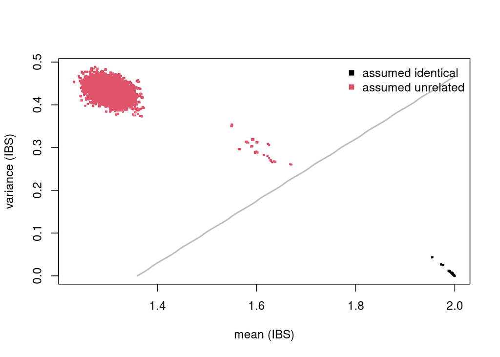

```r
str(mismatches)
```

```
## 'data.frame':    0 obs. of  6 variables:
##  $ mean      : num
##  $ var       : num
##  $ colnames.x: chr
##  $ colnames.y: chr
##  $ relation  : Factor w/ 2 levels "identical","unrelated":
##  $ predicted : Factor w/ 2 levels "identical","unrelated":
```

Table of mismatches

```r
table(mismatches$relation, mismatches$predicted)
```

```
##
##             identical unrelated
##   identical         0         0
##   unrelated         0         0
```

Save output

```r
save(genotype, relations, out, mismatches, file = "../GOTO_Data/Processing/omicsPrint/GOTO_omicsPrint-blood.Rdata")
```

# Subcutaneous Fat

### Subset Data

First, we save the methylation data from the fat samples

```r
methData_fat <- methData_snps[ ,
                      methData_snps$tissue == "fat"]
methData_fat
```

```
## class: SummarizedExperiment
## dim: 28152 184
## metadata(0):
## assays(1): beta
## rownames(28152): cg19453472 cg07277756 ... cg15974150 cg16040564
## rowData names(7): cpg chr ... gene_HGNC MASK_general
## colnames(184): 203527980082_R07C01 203527980082_R08C01 ...
##   203550300093_R05C01 203550300093_R06C01
## colData names(19): DNA_labnr IOP2_ID ... Basename smoke
```

Save the phenotype information

```r
targets_fat <- as.data.frame(colData(methData_fat))
dim(targets_fat)
```

```
## [1] 184  19
```

Save the beta values

```r
betas_fat <- assay(methData_fat)
dim(betas_fat)
```

```
## [1] 28152   184
```

Check the different data matches

```r
table(rownames(targets_fat) == colnames(betas_fat))
```

```
##
## TRUE
##  184
```

### Assumed relations

Create a data frame of all samples against each other e.g.:

| idx | idy | sample_name_x | sample_name_y |
| --- | --- | --- | --- |
| 001 | 001 | A | A |
| 001 | 002 | A | B |
| 002 | 001 | B | A |
| 002 | 002 | B | B |

There are 2 samples from all individuals, with the same `IOP2_ID` but different `timepoint`

```r
relations <- expand.grid(
  idx = colnames(methData_fat),
  idy = colnames(methData_fat))
```

Save the sample name, so we know which samples should match

```r
relations$sample_name_x <- targets_fat[relations$idx, "IOP2_ID"]
relations$sample_name_y <- targets_fat[relations$idy, "IOP2_ID"]
```

Create a relation_type variable and set it as Identical if the samples come from the same individual

```r
relations$relation_type <- "unrelated"
relations$relation_type[relations$sample_name_x == relations$sample_name_y] <- "identical"
```

Show results

```r
table(relations$relation_type)
```

```
##
## identical unrelated
##       368     33488
```

### Genotyping

Calculate genotype using omicsPrint

```r
genotype <- beta2genotype(betas_fat,
                          na.rm=TRUE,
                          minSep = 0.25,
                          minSize = 5,
                          centers = c(0.2, 0.5, 0.8),
                          assayName=NULL)
str(genotype)
```

```
##  int [1:1059, 1:184] 3 3 3 1 3 2 2 3 2 1 ...
##  - attr(*, "dimnames")=List of 2
##   ..$ : chr [1:1059] "cg16398051" "cg09727210" "cg06813297" "cg23489384" ...
##   ..$ : chr [1:184] "203527980082_R07C01" "203527980082_R08C01" "203527980080_R03C01" "203527980080_R04C01" ...
```

Save output

```r
out <- alleleSharing(genotype, relations = relations)
```

```
## Hash relations
```

```
## Pruning 1059 SNPs ...
```

```
## 0 SNPs removed because of low call rate!
```

```
## 0 samples removed because too few SNPs called!
```

```
## Using 1059 polymorphic SNPs to determine allele sharing.
```

```
## Running `square` IBS algorithm!
```

```
## 185 of 17020 (1.09%) ...
```

```
## 13451 of 17020 (79.03%) ...
```

### Identify Mismatches

Plot

```r
mismatches <- inferRelations(out, verbose=TRUE)
```

```
##                   Assumed relation
## Predicted relation identical unrelated
##          identical       275         .
##          unrelated         1     16744
```

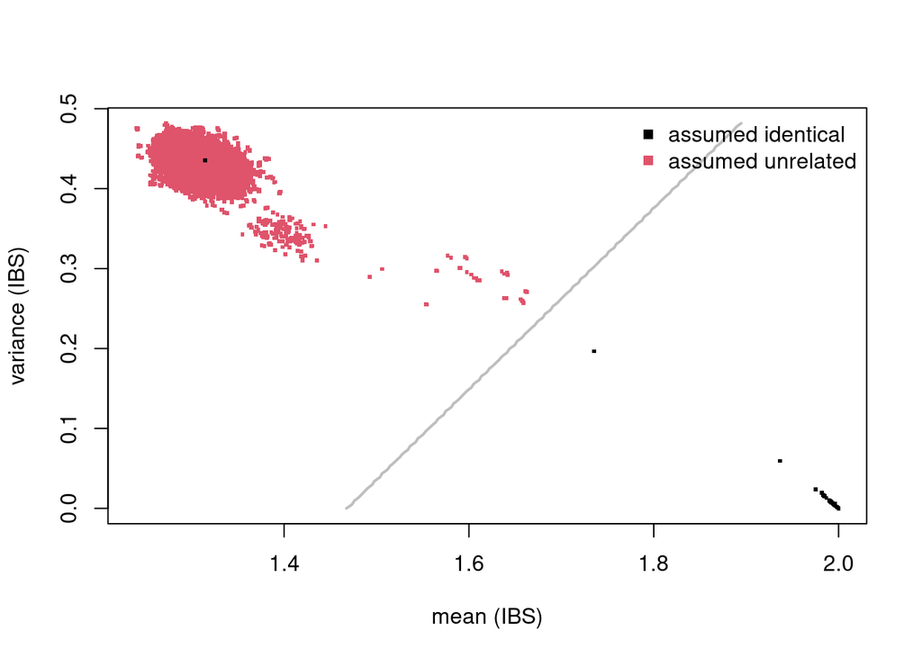

```r
str(mismatches)
```

```
## 'data.frame':    1 obs. of  6 variables:
##  $ mean      : num 1.31
##  $ var       : num 0.435
##  $ colnames.x: chr "203548970042_R06C01"
##  $ colnames.y: chr "203548970042_R05C01"
##  $ relation  : Factor w/ 2 levels "identical","unrelated": 1
##  $ predicted : Factor w/ 2 levels "identical","unrelated": 2
```

There is one sample pair that should come from the same individual but does not appear to.

```r
table(mismatches$relation, mismatches$predicted)
```

```
##
##             identical unrelated
##   identical         0         1
##   unrelated         0         0
```

Save output

```r
save(genotype, relations, out, mismatches, file = "../GOTO_Data/Processing/omicsPrint/GOTO_omicsPrint-fat.Rdata")
```

# Skeletal Muscle

### Subset Data

First, we save the methylation data from the muscle samples

```r
methData_muscle <- methData_snps[ ,
                      methData_snps$tissue == "muscle"]
methData_muscle
```

```
## class: SummarizedExperiment
## dim: 28152 164
## metadata(0):
## assays(1): beta
## rownames(28152): cg19453472 cg07277756 ... cg15974150 cg16040564
## rowData names(7): cpg chr ... gene_HGNC MASK_general
## colnames(164): 203527980082_R01C01 203527980082_R02C01 ...
##   203550300091_R01C01 203550300091_R02C01
## colData names(19): DNA_labnr IOP2_ID ... Basename smoke
```

Save the phenotype information

```r
targets_muscle <- as.data.frame(colData(methData_muscle))
dim(targets_muscle)
```

```
## [1] 164  19
```

Save the beta values

```r
betas_muscle <- assay(methData_muscle)
dim(betas_muscle)
```

```
## [1] 28152   164
```

Check the different data matches

```r
table(rownames(targets_muscle) == colnames(betas_muscle))
```

```
##
## TRUE
##  164
```

### Assumed relations

Create a data frame of all samples against each other e.g.:

| idx | idy | sample_name_x | sample_name_y |
| --- | --- | --- | --- |
| 001 | 001 | A | A |
| 001 | 002 | A | B |
| 002 | 001 | B | A |
| 002 | 002 | B | B |

There are 2 samples from all individuals, with the same `IOP2_ID` but different `timepoint`

```r
relations <- expand.grid(
  idx = colnames(methData_muscle),
  idy = colnames(methData_muscle))
```

Save the sample name, so we know which samples should match

```r
relations$sample_name_x <- targets_muscle[relations$idx, "IOP2_ID"]
relations$sample_name_y <- targets_muscle[relations$idy, "IOP2_ID"]
```

Create a relation_type variable and set it as Identical if the samples come from the same individual

```r
relations$relation_type <- "unrelated"
relations$relation_type[relations$sample_name_x == relations$sample_name_y] <- "identical"
```

Show results

```r
table(relations$relation_type)
```

```
##
## identical unrelated
##       328     26568
```

### Genotyping

Calculate genotype using omicsPrint

```r
genotype <- beta2genotype(betas_muscle,
                          na.rm=TRUE,
                          minSep = 0.25,
                          minSize = 5,
                          centers = c(0.2, 0.5, 0.8),
                          assayName=NULL)
str(genotype)
```

```
##  int [1:1010, 1:164] 1 2 3 3 1 3 3 3 2 3 ...
##  - attr(*, "dimnames")=List of 2
##   ..$ : chr [1:1010] "cg11418303" "cg16398051" "cg09727210" "cg23489384" ...
##   ..$ : chr [1:164] "203527980082_R01C01" "203527980082_R02C01" "203527980082_R03C01" "203527980082_R04C01" ...
```

Save output

```r
out <- alleleSharing(genotype, relations = relations)
```

```
## Hash relations
```

```
## Pruning 1010 SNPs ...
```

```
## 0 SNPs removed because of low call rate!
```

```
## 0 samples removed because too few SNPs called!
```

```
## Using 1010 polymorphic SNPs to determine allele sharing.
```

```
## Running `square` IBS algorithm!
```

```
## 165 of 13530 (1.22%) ...
```

```
## 11451 of 13530 (84.63%) ...
```

### Identify Mismatches

Plot

```r
mismatches <- inferRelations(out, verbose=TRUE)
```

```
##                   Assumed relation
## Predicted relation identical unrelated
##          identical       244         2
##          unrelated         2     13282
```

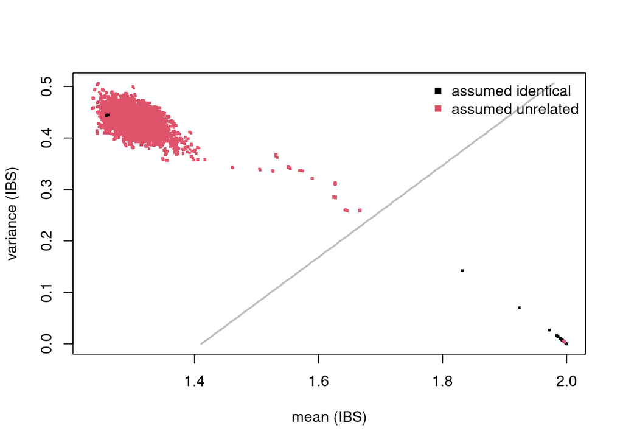

```r
str(mismatches)
```

```
## 'data.frame':    4 obs. of  6 variables:
##  $ mean      : num  1.26 2 2 1.26
##  $ var       : num  0.44452 0.00296 0.00493 0.44356
##  $ colnames.x: chr  "203548970088_R08C01" "203548980011_R03C01" "203548980011_R04C01" "203548980011_R04C01"
##  $ colnames.y: chr  "203548970088_R07C01" "203548970088_R07C01" "203548970088_R08C01" "203548980011_R03C01"
##  $ relation  : Factor w/ 2 levels "identical","unrelated": 1 2 2 1
##  $ predicted : Factor w/ 2 levels "identical","unrelated": 2 1 1 2
```

There are two sample pairs that should match but don’t, perhaps representing a sample swap.

```r
table(mismatches$relation, mismatches$predicted)
```

```
##
##             identical unrelated
##   identical         0         2
##   unrelated         2         0
```

Save output

```r
save(genotype, relations, out, mismatches, file = "../GOTO_Data/Processing/omicsPrint/GOTO_omicsPrint-muscle.Rdata")
```

Clear

```r
rm(list=ls())
```